# COD Reproducibility Report

## Step 4: Run analysis

### Pre-processing

Discrimination index (d’), i.e. accuracy, was calculated according to [Snodgrass & Corwin (1988)] (http://wixtedlab.ucsd.edu/publications/Psych%20218/Snodgrass_Corwin_1988.pdf) (Besson et al., p. 36).

Discrimination index:
$$d' = z_H - z_F$$

where $z_F$ = z-score of false alarm rate and $z_H$ is the z-score of hit rate

The effect of inversion was computed by calculating the difference between inverted face accuracy and upright faces accuracy divided by the upright faces accuracy.

```r
library(data.table)
dt = data.table(tidy_data)

##### Subject-Specific Hit And FA Rates #####
dt[, n.targets := sum( ExpectedResp, na.rm=TRUE ), by=list( subID, Task, InvCond ) ]
dt[, n.hits := sum( accuracy=="Hit" ), by=list( subID, Task, InvCond ) ]
dt[, hit.rate := n.hits/n.targets, by=list( subID, Task, InvCond ) ]
# this matches author's calculation of 50/70 for first cell and subject 1

# false-alarm rates
dt[, n.distr := sum( ExpectedResp==0, na.rm=TRUE ), by=list( subID, Task, InvCond ) ]
dt[, n.fa := sum( accuracy=="FalseAlarm" ), by=list( subID, Task, InvCond ) ]
dt[, fa.rate := n.fa/n.distr, by=list( subID, Task, InvCond ) ]

# Snodgrass versions for later calculation of d'
dt[, hit.rate.c := (n.hits+0.5)/(n.targets+1), by=list( subID, Task, InvCond ) ]
dt[, fa.rate.c := (n.fa+0.5)/(n.distr+1), by=list( subID, Task, InvCond ) ]




##### Average Hit Rates By Task and Inversion #####

# dt2: keep only 1 row per subject, 1 for each task and inversion combination
# hackily make a variable that's unique for each of those combos
dt$temp = paste( dt$subID, dt$Task, dt$InvCond )
dt2 = dt[ !duplicated(dt$temp), ]
dim(dt2)
```

```
## [1] 162  25
```

```r
# indeed, this has 27*2*3 rows
# these hit and FA rates match the originals :)


##### D-Prime By Subject #####
# Z-score, unpooled
# passed arguments should already have Snodgrass correction
dprime = function(f, h){
  return( -qnorm(f) + qnorm(h) )
}

# ref: https://cogsci.stackexchange.com/questions/6302/two-different-values-for-criterion-in-signal-detection-theory
cbias = function( f, h ){
  return( -0.5 * ( qnorm(f) + qnorm(h) ) )
}

dt2[, d := dprime( f=fa.rate.c, h=hit.rate.c ) ]
# these also match! :D


##### Response Bias (C) By Subject #####
dt2[, C := cbias( f=fa.rate.c, h=hit.rate.c ) ]
# these also match! :D


##### "Success" By Subject #####
# not sure, but I assume they use the uncorrected hit and fa rates here
# pass the raw numbers of FAs, hits, and denominators for each
# return binary result of 2-sided, 2-sample Z-test
succeeded = Vectorize( function( f.count, h.count, nf, nh ){
  return( prop.test( x=c(f.count, h.count), n=c(nf, nh) )$p.value < 0.05 )
}, vectorize.args=c("f.count", "h.count", "nf", "nh") )

dt2$success = succeeded( f.count=dt2$n.fa, h.count=dt2$n.hits, nf=dt2$n.distr, nh=dt2$n.targets )

# look at success by condiiton
aggregate( success ~ Task + InvCond, dt2, sum)
```

```
##   Task  InvCond success
## 1  FFR  Upright      24
## 2  HFC  Upright      27
## 3  IFR  Upright      27
## 4  FFR Inverted       4
## 5  HFC Inverted      27
## 6  IFR Inverted      27
```

```r
# indeed, 3 subjects failed

# subjects to exclude
excl.ids = dt2[ dt2$Task=="FFR" & dt2$InvCond=="Upright" & dt2$success==0,]$subID

# exclude them
dt2 = dt2[ !dt2$subID %in% excl.ids, ]


##### Accuracy as Percent #####
d3 = data.frame(dt2)
d3 = d3[ , names(d3) %in% c("subID", "InvCond", "Task", "d") ]


d_inv <- d3 %>%
  group_by(Task, subID, InvCond) %>%
  spread(InvCond, d) %>%
  mutate(inv.eff = (Upright - Inverted)/Upright) #effect of inversion on accuracy

# sanity check: compare to Fig 2B
aggregate( inv.eff ~ Task, data = d_inv, median )
```

```
##   Task    inv.eff
## 1  FFR 0.90091863
## 2  HFC 0.09453308
## 3  IFR 0.42688470
```

### Descriptive statistics

The mean and standard deviations of d’ and of effect of inversion were calculated.

```r
# means and sds by condition
aggregate( d ~ Task + InvCond, dt2, mean)
```

```
##   Task  InvCond         d
## 1  FFR  Upright 1.0612637
## 2  HFC  Upright 4.2030441
## 3  IFR  Upright 3.9633464
## 4  FFR Inverted 0.1336783
## 5  HFC Inverted 3.8504240
## 6  IFR Inverted 2.1797973
```

```r
aggregate( d ~ Task + InvCond, dt2, sd)
```

```
##   Task  InvCond         d
## 1  FFR  Upright 0.4143197
## 2  HFC  Upright 0.5155895
## 3  IFR  Upright 0.4690712
## 4  FFR Inverted 0.2833638
## 5  HFC Inverted 0.5626069
## 6  IFR Inverted 0.3660549
```

These descriptive statistics appear to match the reported descriptive statistics:

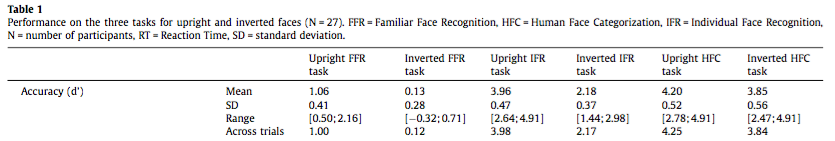

Besson et al. Descriptive Statistics

Let’s check explictly:

```r
###FFR
##Upright
#mean:
reportObject <- compareValues2(reportedValue = "1.06", obtainedValue = 1.06, valueType = 'mean')
```

```
## [1] "MATCH for mean. The reported value (1.06) and the obtained value (1.06) differed by 0%. NB obtained value was rounded to 2 decimal places."
```

```r
#stdev:
reportObject <- compareValues2(reportedValue = "0.41", obtainedValue = 0.41, valueType = 'sd')
```

```
## [1] "MATCH for sd. The reported value (0.41) and the obtained value (0.41) differed by 0%. NB obtained value was rounded to 2 decimal places."
```

```r
##Inverted
#mean:
reportObject <- compareValues2(reportedValue = ".13", obtainedValue = 0.13, valueType = 'mean')
```

```
## [1] "MATCH for mean. The reported value (0.13) and the obtained value (0.13) differed by 0%. NB obtained value was rounded to 2 decimal places."
```

```r
#stdev:
reportObject <- compareValues2(reportedValue = ".28", obtainedValue = 0.28, valueType = 'sd')
```

```
## [1] "MATCH for sd. The reported value (0.28) and the obtained value (0.28) differed by 0%. NB obtained value was rounded to 2 decimal places."
```

```r
###HFC
##Upright
#mean:
reportObject <- compareValues2(reportedValue = "4.20", obtainedValue = 4.20, valueType = 'mean')
```

```
## [1] "MATCH for mean. The reported value (4.2) and the obtained value (4.2) differed by 0%. NB obtained value was rounded to 2 decimal places."
```

```r
#stdev:
reportObject <- compareValues2(reportedValue = "0.52", obtainedValue = 0.52, valueType = 'sd')
```

```
## [1] "MATCH for sd. The reported value (0.52) and the obtained value (0.52) differed by 0%. NB obtained value was rounded to 2 decimal places."
```

```r
##Inverted
#mean:
reportObject <- compareValues2(reportedValue = "3.85", obtainedValue = 3.85, valueType = 'mean')
```

```
## [1] "MATCH for mean. The reported value (3.85) and the obtained value (3.85) differed by 0%. NB obtained value was rounded to 2 decimal places."
```

```r
#stdev:
reportObject <- compareValues2(reportedValue = "0.56", obtainedValue = 0.56, valueType = 'sd')
```

```
## [1] "MATCH for sd. The reported value (0.56) and the obtained value (0.56) differed by 0%. NB obtained value was rounded to 2 decimal places."
```

```r
###IFR
##Upright
#mean:
reportObject <- compareValues2(reportedValue = "3.96", obtainedValue = 3.96, valueType = 'mean')
```

```
## [1] "MATCH for mean. The reported value (3.96) and the obtained value (3.96) differed by 0%. NB obtained value was rounded to 2 decimal places."
```

```r
#stdev:
reportObject <- compareValues2(reportedValue = "0.47", obtainedValue = 0.47, valueType = 'sd')
```

```
## [1] "MATCH for sd. The reported value (0.47) and the obtained value (0.47) differed by 0%. NB obtained value was rounded to 2 decimal places."
```

```r
##Inverted
#mean:
reportObject <- compareValues2(reportedValue = "2.18", obtainedValue = 2.18, valueType = 'mean')
```

```
## [1] "MATCH for mean. The reported value (2.18) and the obtained value (2.18) differed by 0%. NB obtained value was rounded to 2 decimal places."
```

```r
#stdev:
reportObject <- compareValues2(reportedValue = "0.37", obtainedValue = 0.37, valueType = 'sd')
```

```
## [1] "MATCH for sd. The reported value (0.37) and the obtained value (0.37) differed by 0%. NB obtained value was rounded to 2 decimal places."
```

### Inferential statistics

> A repeated measures two-way ANOVA on accuracy with task and orientation as factors revealed a clear main effect of the task (F(2, 22) = 784.6; p < 0.0005) and of the orientation (F(1, 23) = 402.3; p < 0.0005), as well as a significant interaction between them (F(2, 22) = 60.2; p < 0.0005).

```r
aov.out <- aov_ez(data = dt2, id = "subID", within = c("Task", "InvCond"), dv = "d", anova_table = list(correction = "none", es = "pes"), type = "III")

# compare values
reportObject <- compareValues2(reportedValue="2", obtainedValue=aov.out$anova_table$`num Df`[1], valueType = 'df')
```

```
## [1] "MATCH for df. The reported value (2) and the obtained value (2) differed by 0%. NB obtained value was rounded to 0 decimal places."
```

```r
reportObject <- compareValues2(reportedValue="22", obtainedValue=aov.out$anova_table$`den Df`[1], valueType = 'df')
```

```
## [1] "MAJOR NUMERICAL ERROR for df. The reported value (22) and the obtained value (46) differed by 109.09%. NB obtained value was rounded to 0 decimal places."
```

```r
reportObject <- compareValues2(reportedValue="784.6", obtainedValue=aov.out$anova_table$F[1], valueType = 'F')
```

```
## [1] "MINOR NUMERICAL ERROR for F. The reported value (784.6) and the obtained value (797.3) differed by 1.62%. NB obtained value was rounded to 1 decimal places."
```

```r
reportObject <- compareValues2(reportedValue="eyeballMATCH", obtainedValue=aov.out$anova_table$`Pr(>F)`[1], valueType = 'p')
```

```
## [1] "MATCH for p. Eyeball comparison only."
```

```r
reportObject <- compareValues2(reportedValue="1", obtainedValue=aov.out$anova_table$`num Df`[2], valueType = 'df')
```

```
## [1] "MATCH for df. The reported value (1) and the obtained value (1) differed by 0%. NB obtained value was rounded to 0 decimal places."
```

```r
reportObject <- compareValues2(reportedValue="23", obtainedValue=aov.out$anova_table$`den Df`[2], valueType = 'df')
```

```
## [1] "MATCH for df. The reported value (23) and the obtained value (23) differed by 0%. NB obtained value was rounded to 0 decimal places."
```

```r
reportObject <- compareValues2(reportedValue="402.3", obtainedValue=aov.out$anova_table$F[2], valueType = 'F')
```

```
## [1] "MINOR NUMERICAL ERROR for F. The reported value (402.3) and the obtained value (399.4) differed by 0.72%. NB obtained value was rounded to 1 decimal places."
```

```r
reportObject <- compareValues2(reportedValue="eyeballMATCH", obtainedValue=aov.out$anova_table$`Pr(>F)`[2], valueType = 'p')
```

```
## [1] "MATCH for p. Eyeball comparison only."
```

```r
reportObject <- compareValues2(reportedValue="2", obtainedValue=aov.out$anova_table$`num Df`[3], valueType = 'df')
```

```
## [1] "MATCH for df. The reported value (2) and the obtained value (2) differed by 0%. NB obtained value was rounded to 0 decimal places."
```

```r
reportObject <- compareValues2(reportedValue="22", obtainedValue=aov.out$anova_table$`den Df`[3], valueType = 'df')
```

```
## [1] "MAJOR NUMERICAL ERROR for df. The reported value (22) and the obtained value (46) differed by 109.09%. NB obtained value was rounded to 0 decimal places."
```

```r
reportObject <- compareValues2(reportedValue="60.2", obtainedValue=aov.out$anova_table$F[3], valueType = 'F')
```

```
## [1] "MAJOR NUMERICAL ERROR for F. The reported value (60.2) and the obtained value (50.9) differed by 15.45%. NB obtained value was rounded to 1 decimal places."
```

```r
reportObject <- compareValues2(reportedValue="eyeballMATCH", obtainedValue=aov.out$anova_table$`Pr(>F)`[3], valueType = 'p')
```

```
## [1] "MATCH for p. Eyeball comparison only."
```

> the effect of inversion was computed (i.e. the difference between inverted face accuracy and upright faces accuracy divided by the upright faces accuracy; e.g. Russell, Duchaine, & Nakayama, 2009) and showed a significant difference between the three task (F(2, 22) = 151.4; p < 0.0005).

```r
aov.out <- aov_ez(d = d_inv, id = 'subID', dv = "inv.eff", within = 'Task', anova_table = list(correction = "none", es = "pes"), type = "III")

reportObject <- compareValues2(reportedValue = "2", obtainedValue = aov.out$anova_table$`num Df`, valueType = 'df')
```

```
## [1] "MATCH for df. The reported value (2) and the obtained value (2) differed by 0%. NB obtained value was rounded to 0 decimal places."
```

```r
reportObject <- compareValues2(reportedValue = "22", obtainedValue = aov.out$anova_table$`den Df`, valueType = 'df')
```

```
## [1] "MAJOR NUMERICAL ERROR for df. The reported value (22) and the obtained value (46) differed by 109.09%. NB obtained value was rounded to 0 decimal places."
```

```r
reportObject <- compareValues2(reportedValue = "151.4", obtainedValue = aov.out$anova_table$F, valueType = 'F')
```

```
## [1] "MAJOR NUMERICAL ERROR for F. The reported value (151.4) and the obtained value (109.8) differed by 27.48%. NB obtained value was rounded to 1 decimal places."
```

```r
reportObject <- compareValues2(reportedValue = "eyeballMATCH", obtainedValue = aov.out$anova_table$`Pr(>F)`, valueType = 'p')
```

```
## [1] "MATCH for p. Eyeball comparison only."
```

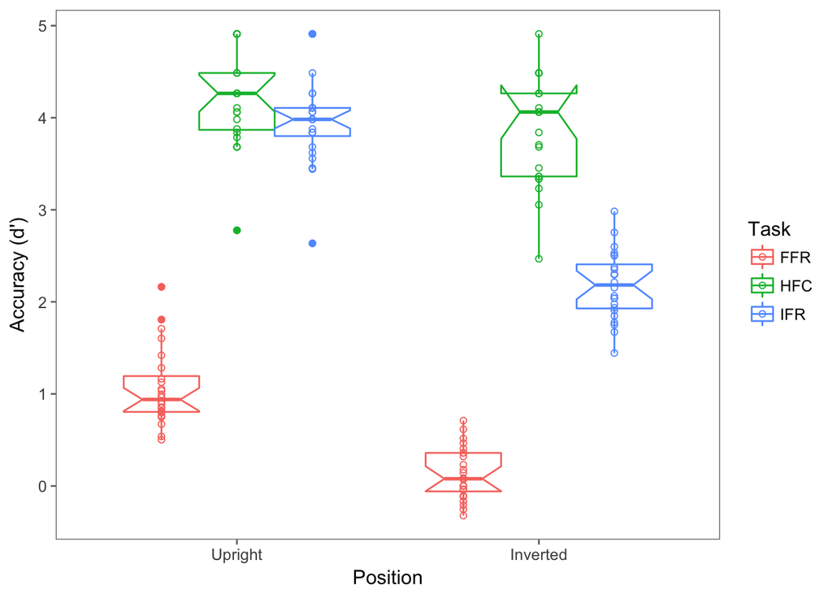

```r
ggplot(data=dt2,
  aes(x = InvCond, y = d, color = Task)) +
  geom_boxplot(notch=TRUE) +
  geom_point(shape=21, position=position_dodge(width=0.75)) +
  ggthemes::theme_few() +
  xlab("Position") +
  ylab("Accuracy (d')")
```

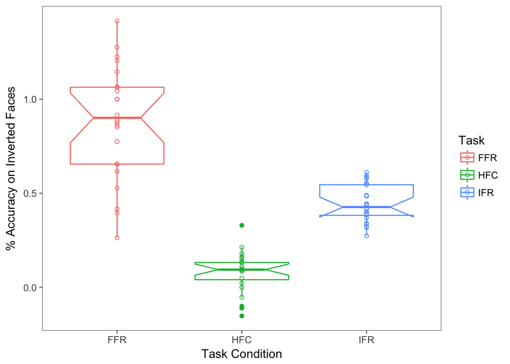

```r
ggplot(data=d_inv,
  aes(x = Task, y = inv.eff, color = Task))+
  geom_boxplot(notch=TRUE) +
  geom_point(shape=21, position=position_dodge(width=0.75)) +
  ggthemes::theme_few() +
  xlab("Task Condition") +
  ylab("% Accuracy on Inverted Faces")
```

## Step 5: Conclusion

I initially could not reproduce the by-participant dataset from the by-trial data, but after contacting the author and receiving a prompt reply, I could exactly reproduce the by-participant dataset and corresponding descriptive statistics. The procedures I had done incorrectly were perhaps not entirely detailed in the paper, but I suspect that a reader with background in signal detection theory would have understood these procedures as standard practice.

Results of the two main analyses and corresponding marginal means yielded effect sizes similar to those in the original paper, but that differed numerically. F-statistics were sometimes substantially different, although direct comparison is difficult because our analyses also differed on degrees of freedom. We followed up with the authors a second time to address these issues but received no response to our initial e-mail or a 2 week follow up reminder. As the issues cannot be resolved, this reproducibility check has to be marked as a failure depsite author assistance.

```r
reportObject$Article_ID <- "KIUKz"
reportObject$affectsConclusion <- "no"
reportObject$error_typo <- 0
reportObject$error_specification <-
reportObject$error_analysis <- 0
reportObject$error_data <- 0
reportObject$error_unidentified <- 1
reportObject$Author_Assistance <- T
reportObject$resolved_typo <- 0
reportObject$resolved_specification <- 1
reportObject$resolved_analysis <- 0
reportObject$resolved_data <- 0
reportObject$correctionSuggested <- F
reportObject$correctionPublished <- NA

# decide on final outcome
if(reportObject$Decision_Errors > 0 | reportObject$Major_Numerical_Errors > 0 | reportObject$Insufficient_Information_Errors > 0){
  reportObject$finalOutcome <- "Failure"
  if(reportObject$Author_Assistance == T){
    reportObject$finalOutcome <- "Failure despite author assistance"
  }
}else{
  reportObject$finalOutcome <- "Success"
  if(reportObject$Author_Assistance == T){
    reportObject$finalOutcome <- "Success with author assistance"
  }
}

# save the report object
filename <- paste0("reportObject_", reportObject$Article_ID,".csv")
write_csv(reportObject, filename)
```

## Report Object

| valuesChecked | eyeballs | Total_df | Total_p | Total_mean | Total_sd | Total_se | Total_ci | Total_bf |
| --- | --- | --- | --- | --- | --- | --- | --- | --- |
| 28 | 4 | 8 | 4 | 6 | 6 | 0 | 0 | 0 |

| Total_t | Total_F | Total_es | Total_median | Total_irr | Total_r | Total_z | Total_coeff | Total_n | Total_x2 |
| --- | --- | --- | --- | --- | --- | --- | --- | --- | --- |
| 0 | 4 | 0 | 0 | 0 | 0 | 0 | 0 | 0 | 0 |

| Total_other | Insufficient_Information_Errors | Decision_Errors | Major_Numerical_Errors | Minor_Numerical_Errors |
| --- | --- | --- | --- | --- |
| 0 | 0 | 0 | 5 | 2 |

| Major_df | Major_p | Major_mean | Major_sd | Major_se |
| --- | --- | --- | --- | --- |
| 3 | 0 | 0 | 0 | 0 |

| Major_ci | Major_bf | Major_t | Major_F | Major_es |
| --- | --- | --- | --- | --- |
| 0 | 0 | 0 | 2 | 0 |

| Major_median | Major_irr | Major_r | Major_z | Major_coeff |
| --- | --- | --- | --- | --- |
| 0 | 0 | 0 | 0 | 0 |

| Major_n | Major_x2 | Major_other | affectsConclusion | error_typo |
| --- | --- | --- | --- | --- |
| 0 | 0 | 0 | no | 0 |

| error_specification | error_analysis | error_data | error_unidentified | Author_Assistance | resolved_typo |
| --- | --- | --- | --- | --- | --- |
| 0 | 0 | 0 | 1 | TRUE | 0 |

| resolved_specification | resolved_analysis | resolved_data | correctionSuggested | correctionPublished | finalOutcome |
| --- | --- | --- | --- | --- | --- |
| 1 | 0 | 0 | FALSE | NA | Failure despite author assistance |

[output not shown]

[output cut: 176 more lines]

[output not shown]